# Take Home Exercise 3

In this exercise, we shall apply the skills we had learned in last two lessons to create data visualisation by using appropriate data visualisation techniques.

Reynard Lam https://www.linkedin.com/in/reynard-lam-570644133/ (School of Computing and Information Systems, SMU)https://scis.smu.edu.sg/  
2022-02-19

## Tasks

In this take-home exercise, we are required to apply appropriate data visualisation techniques to accomplish the task given below:

“Create a data visualisation showing average rating and proportion of cocoa percent (% chocolate) greater than or equal to 70% by top 15 company location. For the purpose of this task, *chocolate.csv* should be used.”

## Data Preparation

### Installing and Launching R Packages

Before we get started, we will need to install the relevant R packages.

```r
packages = c('ggpubr', 'tidyverse', 'readxl', 'knitr','plotly','ggdist', 'distributional')

for(p in packages){library
  if(!require(p, character.only = T)){
    install.packages(p)
  }

  library(p, character.only = T)
}
```

### Importing Data

First, let us import the data into R by using the *read.csv* function.

```r
chocdata <- read.csv("data/chocolate.csv")
```

Checking the data types of the columns in our dataframe shows that the *rating* column is in numeric format but the *cocoa_percent* column is in character format.

```r
str(chocdata)
```

```
'data.frame':   2530 obs. of  10 variables:
 $ ref                             : int  2454 2458 2454 2542 2546 2546 2542 797 797 1011 ...
 $ company_manufacturer            : chr  "5150" "5150" "5150" "5150" ...
 $ company_location                : chr  "U.S.A." "U.S.A." "U.S.A." "U.S.A." ...
 $ review_date                     : int  2019 2019 2019 2021 2021 2021 2021 2012 2012 2013 ...
 $ country_of_bean_origin          : chr  "Tanzania" "Dominican Republic" "Madagascar" "Fiji" ...
 $ specific_bean_origin_or_bar_name: chr  "Kokoa Kamili, batch 1" "Zorzal, batch 1" "Bejofo Estate, batch 1" "Matasawalevu, batch 1" ...
 $ cocoa_percent                   : chr  "76%" "76%" "76%" "68%" ...
 $ ingredients                     : chr  "3- B,S,C" "3- B,S,C" "3- B,S,C" "3- B,S,C" ...
 $ most_memorable_characteristics  : chr  "rich cocoa, fatty, bready" "cocoa, vegetal, savory" "cocoa, blackberry, full body" "chewy, off, rubbery" ...
 $ rating                          : num  3.25 3.5 3.75 3 3 3.25 3.5 3.5 3.75 2.75 ...
```

### Cleaning Data

Before we proceed further, we will need to convert the *cocoa_percent* column to numeric format in order to perform further calculations on the data.

```r
chocdata <- chocdata %>%
  mutate(cocoa_percent = parse_number(cocoa_percent))
```

Checking the data types of the columns once more, we can see that the *cocoa_percent* column have been converted to numeric format.

```r
str(chocdata)
```

```
'data.frame':   2530 obs. of  10 variables:
 $ ref                             : int  2454 2458 2454 2542 2546 2546 2542 797 797 1011 ...
 $ company_manufacturer            : chr  "5150" "5150" "5150" "5150" ...
 $ company_location                : chr  "U.S.A." "U.S.A." "U.S.A." "U.S.A." ...
 $ review_date                     : int  2019 2019 2019 2021 2021 2021 2021 2012 2012 2013 ...
 $ country_of_bean_origin          : chr  "Tanzania" "Dominican Republic" "Madagascar" "Fiji" ...
 $ specific_bean_origin_or_bar_name: chr  "Kokoa Kamili, batch 1" "Zorzal, batch 1" "Bejofo Estate, batch 1" "Matasawalevu, batch 1" ...
 $ cocoa_percent                   : num  76 76 76 68 72 80 68 70 63 70 ...
 $ ingredients                     : chr  "3- B,S,C" "3- B,S,C" "3- B,S,C" "3- B,S,C" ...
 $ most_memorable_characteristics  : chr  "rich cocoa, fatty, bready" "cocoa, vegetal, savory" "cocoa, blackberry, full body" "chewy, off, rubbery" ...
 $ rating                          : num  3.25 3.5 3.75 3 3 3.25 3.5 3.5 3.75 2.75 ...
```

Next, we will be preparing the data for rating and cocoa percent by company. First, a filter was applied on the *cocoa_percent* column to filter out cocoa percentages greater than or equal to 70%. Next, the dataset was grouped by company manufacturer for the rating and cocoa percent, and statistics such as the mean, count, standard deviation and standard error was calculated.

Next, two separate dataframes were created, one for cocoa percent and one for ratings.

Lastly, in order to have a more comprehensive analysis, all company manufacturers with only one rating was excluded from the analysis. To do so, the separate dataframes were filtered for number of ratings via the *n* column

```r
chocdata <- filter(chocdata,cocoa_percent>=70)

choccocoa <- chocdata %>%
  group_by(company_manufacturer) %>%
  summarise(
    n = n(),
    mean = mean(cocoa_percent),
    sd = sd(cocoa_percent)
  ) %>%
  mutate(se = sd/sqrt(n-1))

chocrating <- chocdata %>%
  group_by(company_manufacturer) %>%
  summarise(
    n = n(),
    mean = mean(rating),
    sd = sd(rating)
  ) %>%
  mutate(se = sd/sqrt(n-1))

choccocoa <- filter(choccocoa,n>1)
chocrating <- filter(chocrating,n>1)
```

Next, the dataframes were sorted in descending order by the mean values and the top 15 manufacturers were extracted.

```r
chocrating <- chocrating[order(-chocrating$mean),]
chocrating <- head(chocrating, 15)
choccocoa <- choccocoa[order(-choccocoa$mean),]
choccocoa <- head(choccocoa, 15)
```

## Data Visualisation

Finally, we employ *ggplot* and the *stat_halfeye()* function to show the uncertainty of point estimates for the rating and the cocoa percent for the top 15 manufacturers.

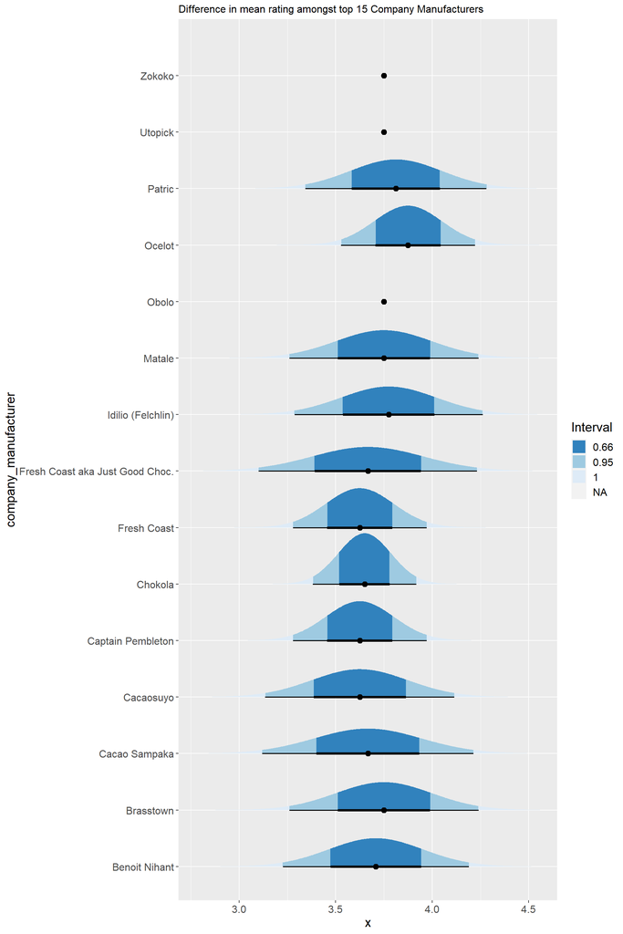

```r
ggplot(chocrating) +
  aes(y = company_manufacturer, xdist = dist_normal(mean,sd)) +
  stat_halfeye(
    aes(
      fill = stat(cut_cdf_qi(cdf),
                  labels = scales::percent_format())

    )) +

  scale_fill_brewer(direction = -1) +
  theme(text = element_text(size=15)) +
  theme(plot.title = element_text(size=12)) +
  labs(
    fill = "Interval")+
  ggtitle("Difference in mean rating amongst top 15 Company Manufacturers")
```

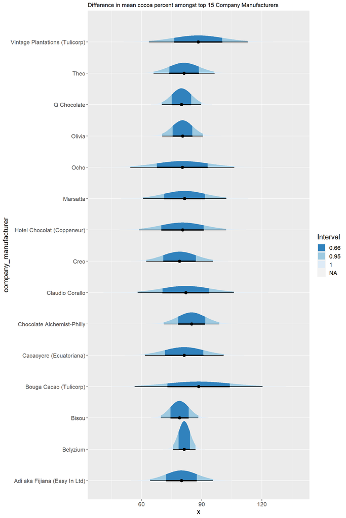

```r
ggplot(choccocoa) +
  aes(y = company_manufacturer, xdist = dist_normal(mean,sd)) +
  stat_halfeye(
    aes(
      fill = stat(cut_cdf_qi(cdf),
                  labels = scales::percent_format())
    )

  ) +

  scale_fill_brewer(direction = -1) +

  theme(text = element_text(size=15)) +
  theme(plot.title = element_text(size=12)) +
  labs(
    fill = "Interval")+
  ggtitle("Difference in mean cocoa percent amongst top 15 Company Manufacturers")
```